```python
%matplotlib inline
```

# WYTEC - Python Coding and Data Management

Dr. Diego Ibarra  
Contact: https://diegoibarra.ca/

## Install/Download BEFORE the workshop (you probably already did this)

Do the following BEFORE the beginning of the workshop (ideally the day before). This takes about 40 minutes, at reasonably good internet speed.

1. Create a new folder in your computer, and name it **WYTEC_Python_Workshop**.
2. Go to this Google-Drive folder, download the following 3 data files and place them in your newly created **WYTEC_Python_Workshop** folder.
   - buoy_data.csv
   - glider_data.cs
   - satellite_da.nc
3. Install **Anaconda**, which is a free "bundle" of Python and many modules, libraries and other programs commonly used in scientific research. Please install **Anaconda** from here: https://www.anaconda.com/download
4. Once **Anaconda** finishes installing, open the **Anaconda Navigator**. Sometimes this is automatically opened after the installation finishes. If not, search in the Windows Taskbar (in Mac, search in the Launchpad) for "Anaconda Navigator".
5. Once Anaconda Navigator is open, take a look at the available applications, find the application named “**Spyder**”. If it is already installed, there will be a “Launch” button… if it is NOT installed, there will be a “Install” button. Make sure **Spyder** is installed (by clicking on the ”Install” button)… but you may NOT want to “launch” it just yet. Wait until you finish installing the packages shown below.
6. Open the **Anaconda Prompt** . Easiest way is by searching in the Windows Taskbar the term "Anaconda Prompt" (in Mac, search in the Launchpad for "Terminal"). Then follow the next ste to install 3 modules (i.e. netcdf4, cartopy and cmocean):
- Install `netcdf4`, by copy-pasting in the **Anaconda Prompt (or Terminal)**:

conda install -c anaconda netcdf4

- Click [Enter]
- If it asks you "are you sure?", type "y" and click [Enter] again.
- Install `cartopy`, by copy-pasting in the **Anaconda Prompt (or Terminal)**:

conda install -c conda-forge cartopy

- Click [Enter]
- If it asks you "are you sure?", type "y" and click [Enter] again.
- Install `cmocean`, by copy-pasting in the **Anaconda Prompt (or Terminal)**:

conda install -c conda-forge cmocean

- Click [Enter]
- If it asks you "are you sure?", type "y" and click [Enter] again.

## Workshop mechanics (how to work through this workshop)

For this workshop you will need 2 programs (sometimes 3):

1. **Workshop manual**: It is this web-page, which has the instructions on what to do in the lab. If you are reading "this" you already found Workshop manual.
2. **Spyder**: This is the main program where you will use to write and run Python code. We'll talk more about **Spyder** below.
3. **Terminal**: Every once in a while you will need to install additional Python modules. This is done in the **Terminal**. More on this below.

In this workshop, you will be required to read along the **Workshop manual** and copy-paste code from the **Workshop manual** into **Spyder** to run it. This will create output in the form of numbers, graphs, maps, etc. So you will be jumping back and forth between the **Workshop manual** and **Spyder** throughout the Workshop. Every once in a while you will need to answer questions, which are written inside orange boxes like the one below. The questions are just bring focus to elements that should be paying attention to. However, there is no grade associated with the questions. It is up to you to try to solve the correctly.

THIS is just a sample question to show you how questions look like. All good to continue?

## Where is my code?

Data, code and the results produced by the code can be stored in many places, including **"the cloud"** (e.g. Google-Drive, GitHub, a website, etc.) and physical computers including the computer that you are working on at this moment. Additionally, within your computer, data and code can be stored in the **hard-drive**, in **memory** and on the **screen**.

[figure not shown]

Note that:

- **Computers** can ONLY see and work with code and data stored in **memory**
- **Humans** can ONLY see code and data shown on the **screen**
- When turning your computer off, code/data in both the **memory** and the **screen** are lost forever! Therefore, make sure that you save your work on your **hard-drive** or **the cloud**, before turning your computer off.

We will see below how to move code (and data) between all these storage areas (i.e. memory, hard-drive, screen, cloud). keeping track of where is your code/data stored, is one of the most common sources of errors during coding.

## Anaconda (downloading and installing Python)

[figure not shown]

There are many ways to install Python. Here, we'll used one of the most common methods... we installed `Anaconda` (likely you already did this earlier, in preparation for this workshop!). `Anaconda` is a free "bundle" of Python and many modules, libraries and other programs commonly used in scientific research. If you haven't done so, please install `Anaconda` from here: https://www.anaconda.com/download

Note that when you installed `Anaconda`, a lot of code was copied from **"The Cloud"** into your **hard-drive**, in a location that we will call "the Python Directory". The actual location of "the Python Directory" is not important to us in this workshop. However if you are curious and try to find it, just make sure that you **DO NOT** move, delete or add anything within "the Python Directory"! You can break Python's proper functioning.

## Spyder

[figure not shown]

Most people do "coding" (in any programming language) using an **"Integrated Development Environment" (IDE)**, which are programs designed to make "coding" easier. **IDE's** make it easier to run your code, get help, manage multiple projects and files, color-code your code as you write it, etc. **IDE's** are like a Swiss-army-knife for coding. Many **IDE's** are free. Take a look at [this list of IDE's](https://en.wikipedia.org/wiki/Comparison_of_integrated_development_environments)

In this lab, we'll use **Spyder**, which is a free "Integrated Development Environment" that comes included in `Anaconda` and that is especially designed to work with Python. You should already have it installed in your computer if you downloaded `Anaconda`.

- To open ***Spyder***, search in the taskbar for "Spyder", the program looks as follows:

[figure not shown]

Note that when you open **Spyder**, behind the scenes a bunch of code was loaded into **memory** from "the Python Directory" (i.e. **hard-drive**).

### Spyder's overview

The Spyder screen is divided in multiple panels. The two most important are the ***Console*** and the ***Editor***.

[figure not shown]

### Spyder's "Console"

The ***Console*** (also known as the interpreter) is a live instance of Python. This is the place where Python will display error messages, warnings, and some code output. The ***Console*** is also where you can quickly interact with Python by writing code and then clicking [Enter] (note that when you click [Enter], anything you wrote on the ***Console*** will be loaded to memory and executed immediately).

Note that, to help you figure out what to type in the "Console" and what to type (or copy-paste) in the "Editor", we added a small colored box with instructions above every "code box" (red to type in "Console" and green to type in "Editor").

Let's try it:

```python
print('hello world!')
```

```
hello world!
```

After you typed in the console print('hello world!')... and clicked [Enter]...  
What got displayed on the screen?

### Spyder's "Working Directory"

The **working directory** is the location in your computer **hard-drive** where Spyder is reading and writing files. In the top right corner (usually), Spyder will show you its **working directory**.

[figure not shown]

Make sure that your ancillary data files (and later, the python code that you will be creating), are all saved in the **working directory**. You can download them directly to the **working directory**, or you can change the **working directory** to be folder where you downloaded your files.

To change the **working directory**, simply chick on the "folder" icon and select the new location. When you execute Python code with instructions to write data or a figure to a file, this file will be save by default in the **working directory**.

1. Earlier, in the setup/downloads/installs BEFORE the workshop, you should have created a new folder named **WYTEC_Python_Workshop**. If you didn't, please do so now (see the top of this document for detailed instructions).
2. Change Spyder's **working directory** to point to your newly created **WYTEC_Python_Workshop** folder.

Take a look at Spyder's working directory (top-right corner) to verify that indeed Spyder is pointing to the correct location.

You can also see the location of the **working directory** by typing the following in the console (then press [Enter]):

```python
%pwd
```

```
'C:\\Users\\Diego\\Documents\\WYTEC\\WYTEC_Python_Workshop'
```

You are starting to work on a lab that requires 2 ancillary data files and 3 ancillary python code files. You download all of these files from Google_drive into you Laptop. Which of the following describes best what happened to the data/code?

a) Data/code were copied from "the cloud" to your hard-drive

b) Data/code were copied from "the cloud" to your computers memory

c) Data/code were copied from your hard-drive to your computers memory

d) Data/code were copied from your hard-drive to your screen

You are starting to work on a lab that requires 2 ancillary data files and 3 ancillary python code files. **Where** in your laptop do you have to put these files?

a) Your "working directory"

b) The "Python directory" in your computer

c) The "Downloads" directory in your computer

d) Your Desktop

### Spyder's "Editor"

The **Editor** is the space where you write your code so that you can execute it later. The **Editor** is shown below inside the green box.

[figure not shown]

The **Editor** is just a text editor like Notepad (in Windows) or TextEdit (in Mac). However, Spyder's **Editor** color-codes your text so that it can be read with ease. It will also perform some basic quality control and will tell you if you made a mistake (more on this later).

You can run the code you wrote in the editor by clicking on the "run" button (i.e. green triangular button shown below).

[figure not shown]

Note that the first time you run your code the **Editor** will prompt you to save your file. You can name your file anything you want, but the extension will be automatically set as `.py`, which is the default extension for Python files. Also note that, by default, you will be prompt to save your file in the current **working directory**.

After you write some code in the **Editor**, note that clicking the "save" button technically transfers code from the **Screen** into a file in your **hard-drive**. Also, if you click the "run" button, it automatically saves your code and then loads it into **memory** and executes it!

In Spyder, you can click on [File] > [New file...] to create a new empty Python file.

Make a new file, name it **test1.py**, and save it in your **working directory**.

Note that, to help you figure out when to type or copy-paste into the "Editor" (i.e. NOT in the "Console"), we added a small GREEN colored box with instructions above every "code box".

Lets do a test. Type the following in the **Editor** and click

```python
print('hello world!')
```

```
hello world!
```

As you see, when you run the code in the ***Editor***, the output is displayed in the* **Console***

After you write some code in the **Editor**, what happens when you click the **"save"** button?

a) Code is saved to the hard-drive

b) Code is loaded to memory

c) Code is saved to the cloud

d) Code is loaded to the screen

After you write some code in the **Editor**, what happens when you click the **"run"** button?

a) Code is saved to the hard-drive

b) Code is loaded into memory

c) Code is saved to the cloud

d) Code is loaded to the screen

## When to "Editor"? ...and when to "Console"?

[figure not shown]

It can be tricky to know when to type (or copy-paste) code in the "Editor" and when to do so in the "Console". The "Editor" is best suited for writing long (or medium length) scripts that are self-contained... while the "Console" is best for writing "on the fly" tests that are one or a few lines long.

1. **Editor:** When you use **Editor** you most save your code in a `.py` file before you can it. The advantage of this is that you can re-use your code at a later date. Simply open your `.py` file and it again! Use the **Editor** to write self-contained code (i.e. scripts or little programs) that you may want to re-use a later date. Examples of these self-contained scripts are shown in the real-life case studies below.
2. **Console:** The **Console** is the quickest way to enter code into Python's **"memory"** and the quickest way to query or inspect something that is already in Python's **"memory"**. The drawback is that code written in **Console** quickly disappears as you write new code... or when you turn off Spyder or your computer. Code written in the **Console** is not very re-usable. Therefore, use the **Console** when you need to do "one-offs" or "on the fly" tests.

[figure not shown]

If we use, as an analogy, the development of a new recipe for making "chicken tacos". You may start cooking the recipe as you write each step in your recipe book. When you get to the part about adding salt, you don't know how much salt to add... so you experiment. You start by adding a small amount of salt (1 gr), stir and taste. If it is not enough, you ad another gram... then stir and taste... and so, on until you get the right amount of salt. Then you write in your recipe the final amount of grams of salt.

In this analogy, writing in the recipe book is as writing in Spyder's **"Editor"**. Text here are clean instructions that you will need to read later to cook the recipe, so these instructions better be clean, well written, and in the appropriate order.

Adding salt, stirring and tasting are "on the fly" tests to see if what you are doing is good or needs adjustment. This is the equivalent to writing in Spyder's **"Console"**.

As mentioned earlier, we will be adding "red" or "green" blocks (like the ones below) to guide you when to use the **Console** and when to use the **Editor**...

## Comments and statements

- **Comments** are lines of text meant to be read ONLY by humans (i.e. the computer ignores these lines). Comments usually contain annotations and additional information to make easier to understand the code to the programmer. **Comments** are preceded by a **#** (hashtag)
- A **Statement** is a line of text read by the computer. This is "the code". A statement contains instructions for the computer to do one or more tasks.

Take a look to the sequence of statements below:

```python
# This is a Comment because it is preceded by a # (hashtag)
a = 2

# Lets print our variables to screen
print(a) # Note that comments can be written after a statement (but not before)
```

```
2
```

Above...

- The first line is a **comment**
- The second line is a **statement** assigning the value of `a` to be equal to 2
- Then there is a blank line. Blank lines are ignored by Python (they exist to space the code and make it easier to read).
- The forth line is a **comment**
- The fifth line is a **statement** asking Python to print the value of `a` to screen. After the statement, there is another comment

If you copy-paste the code above to the ***Spyder's Editor*** and click [run], it will print a `2` to the console.

Once `a = 2` has been executed, the value of `a` will be stored "in memory" until you turn off python, until you delete `a`, or until you update `a` with a different value.

## Variables

A **Variable** is a user-defined label that can be used to name anything. For example, in the **statement** above (`a = 2`) "a" is a variable. You can name variables anything you want (no punctuation thought), for example:

```python
my_cute_variable = 35

print(my_cute_variable)
```

```
35
```

Note that it is a good practice to choose variable names that describe what is stored within the variable.

Also note that you can use Spyder's ***Variable explorer*** to see what variables are currently loaded into **memory**.

[figure not shown]

## Sneak-peak of Real-life case study #1: data from an oceanographic buoy in Oregon

Let's take a quick look at what is coming ahead.

Lets use data from an autonomous buoy in the Columbia River (Oregon, USA) that (used to) broadcasts real-time ocean data via the following server: http://columbia.loboviz.com/

| LOBO Buoy | Columbia River (Oregon, USA) |
| --- | --- |

The following code load the buoy's data, and makes a simple plot.

```python
# Import Pandas module
import pandas as pd

# Read data from file
buoy_data = pd.read_csv('buoy_data.csv')

# Do quick plot
buoy_data.plot(x='date [PST]',y='temperature [C]', rot=90)
```

To see the plot you just made, click on the "Plot" tab (beside your "Variable explorer"). See below...

[figure not shown]

It is pretty amazing that you can make a decent plot with just 3 lines of code.

If you take a close look to the code, you can also see some of the principles that we just learned, like "comments" and "statements":

[figure not shown]

You can also see in the code that we created a variable (`buoy_data`) and then we used it to make a plot.

[figure not shown]

But also there is a lot that we have not learned yet, like`modules`, `fundtions`, `methods`, `strings`, `floats`, etc.

[figure not shown]

We are going to learn those concepts next. Then we'll come back to the Real-life scenario #1: The Oregon Buoy.

## Basic data types (or "primitive" data types)

In every computer language there are many data types. Each data type is best suited to handle different data, and also behaves under different rules, thus it is important to always be aware of what data type each statement is working with.

Below are some of the most common data types used in Python:

### Integers

**Integers** are "round" numbers (i.e. no decimal point).

```python
my_int = 2

print(my_int)
```

```
2
```

### Floats

**Floats** are numbers with a decimal point.

```python
my_float = 2.4

print(my_float)
```

```
2.4
```

### Strings

**Strings** are letters. Note that you need to wrap the content of the string within quotes to tell Python they are a string.

```python
# You can use single quotes ' or double quotes " to create strings
my_string_1 = 'hello'

my_string_2 = "2.4"

print(my_string_1)
print(my_string_2)
```

```
hello
2.4
```

#### Note that even though "2.4" is a number, it will be treated by Python as "letters". Therefore you won't be able to do math with "2.4"

What data type is the following: 324.91

a) Integer

b) Float

c) String

d) Boolean

What data type is the following: 'the house is green'

a) Integer

b) Float

c) String

d) Boolean

What data type is the following: 87572

a) Integer

b) Float

c) String

d) Boolean

If you execute the following line in Python...

```
a = 32
```

Then, what is "**32**"?

a) an integer

b) a float

c) a string

d) a variable

If you execute the following line in Python...

```
a = 32
```

Then, what is "**a**"?

a) an integer

b) a float

c) a string

d) a variable

### Simple operations between different data types

You can do math with most of these data types, as long as they are of the same data type. For example:

```python
4 + 7
```

```
11
```

```python
my_int * 7
```

```
14
```

```python
my_float / 2
```

```
1.2
```

Sometimes (not always) you can do math with different data types. However, some quirks and changes may happen to the result. For example, adding an **integer** plus a **float** yields a float.

```python
my_int + my_float
```

```
4.4
```

...but sometimes mixing data types doesn't work. For example, operations between strings and floats (or integers) is not allowed and therefore if you try to do this operation, Python will yield an ERROR.

```python
my_float + my_string_1
```

```
---------------------------------------------------------------------------
TypeError                                 Traceback (most recent call last)
Cell In[15], line 1
----> 1 my_float + my_string_1

TypeError: unsupported operand type(s) for +: 'float' and 'str'
```

"Summing" two strings simply concatenates them together:

```python
my_string_1 + my_string_2
```

```
'hello2.4'
```

If you execute the following lines in Python...

```
a = 3
b = 1
```

Then, what is the result of: *a + b*

a) 4

b) 3

c) '31'

d) '4'

If you execute the following lines in Python...

```
a = '3'
b = '1'
```

Then, what is the result of: *a + b*

a) 4

b) 3

c) '31'

d) '4'

## Objects (lists and dictionaries)

Everything in Python is an object! Even the **basic data types** are objects: Integers are "Integer Objects", floats are "Float Objects", etc. Each type of object behaves under its own set of rules, therefore it is ESSENTIAL to be aware of what type of object is each of your variables.

We already talked about the sometimes called **"primitive objects"** (i.e. integers, floats, strings), however python comes included with some more advanced objects (e.g. lists and dictionaries). Also, when you install new modules, often they come with their own objects (each with their own rules).

Following a "cooking analogy", I like to think "primitive objects" as types of raw ingredients (e.g. liquid, powder, solid) and the more advanced objects can be thought as containers (e.g. bag, basket, jar, shelf).

If you don't know what type of object is a variable, just type **`type(variableName)`**, for example:

```python
my_var = 12.8

type(my_var)
```

```
float
```

### Lists

Lists are similar to "cell-arrays" in Matlab. "Lists" are great when you just want to append items at the end of the list, but you don't care too much about retrieving a particular item within the list.

Let's do a "list"

```python
my_list = [2,5,8,7,1,2,7]

my_list
```

```
[2, 5, 8, 7, 1, 2, 7]
```

To see if a variable is a `list`, you can also use `type`. See below:

```python
type(my_list)
```

```
list
```

To access an item within the list, type its index within square brackets:

```python
my_list[0]
```

```
2
```

Note that in Python, the first index is **zero!**

```python
my_list[1]
```

```
5
```

```python
my_list[2]
```

```
8
```

Negative indices are counted backwards from the last item:

```python
my_list[-1]
```

```
7
```

```python
my_list[-2]
```

```
2
```

To access several items within the list, use a colon (i.e. :)

```python
my_list[2:4]
```

```
[8, 7]
```

```python
my_list[:3]
```

```
[2, 5, 8]
```

```python
my_list[-3:]
```

```
[1, 2, 7]
```

Note that you can put anything you want in a list (i.e. not only integers). For example:

```python
my_other_list = ['a','5',8,'b',1,2.88,7,'x']

my_other_list[-3:]
```

```
[2.88, 7, 'x']
```

Given the following List:  
my_list = [2,5,8,7,1,2,7]  
How do you access the 3rd item in the list (i.e. 8)?

a) my_list[3]

b) my_list[2]

c) my_list[5]

d) my_list[7]

Given the following List:  
my_list = [2,5,8,7,1,2,7]  
How do you access the last 4 items in the list (i.e. 7,1,2,7)?

a) my_list[4]

b) my_list[-4:]

c) my_list[1:4]

d) my_list[2:4]

### Dictionaries

Dictionaries are similar to "structure-arrays" in Matlab. A "Dictionary" stores items in a way that resembles a dictionary. You look up a "keyword" (e.g. "apple") and your immediately get the contents (i.e. "Red round fruit that tastes good").

Dictionaries are great to quickly find a specific item within the dictionary.

Lets make a dictionary:

```python
my_dict = {'name':'Juan', 'age':27, 'gender':'male'}

my_dict
```

```
{'name': 'Juan', 'age': 27, 'gender': 'male'}
```

To see if a variable is a `Dictionary`, you can also use `type`. See below:

```python
type(my_dict)
```

```
dict
```

Let's query the dictionary using the keywords:

```python
my_dict['age']
```

```
27
```

```python
my_dict['name']
```

```
'Juan'
```

Given the following Dictionary:  
my_dict = {'name':'Juan', 'age':27, 'gender':'male'}  
How do you access the contents stored under the 'age' key (i.e. 27)?

a) my_dict['name']

b) my_dict['age']

c) my_dict['gender']

d) None of the above

If you execute the following lines in Python...

```
a = [3,7,1,9]
b = {'1':3, '2':7, '3':1, '4':9 }
```

Then, what type of object is **a**?

a) list

b) dictionary

c) integer

d) float

e) string

If you execute the following lines in Python...

```
a = [3,7,1,9]
b = {'1':3, '2':7, '3':1, '4':9 }
```

Then, what type of object is **b**?

a) list

b) dictionary

c) integer

d) float

e) string

## Functions and methods

**Functions** and **methods** are how you "do stuff" in Python. With one line of code you can do things like calculate a mean, or do a plot, or do a complicated statistical analysis. In essence, both **functions** and **methods** are code that accept an "input", do something to the input, and spits out an "output". The only thing you need to know and remember is the name of the function (or method). Arguably, learning Python is mostly learning the names of the available functions and methods.

### Functions

Functions are used following the "nomenclature" below:

output = FunctionName(input)

We already used a few functions above, namely the "print" function...

```python
print('hello world!')
```

```
hello world!
```

...and the "type" function

```python
type(124.87)
```

```
float
```

In both case the output was simply displayed to screen, which happens when you do not specify what to do with the output. Below are a few examples where the output is saved to a variable:

First lets do a list... and then apply some functions to it.

```python
mylist = [4,7,2,9,6,3,7,8,5,10]


# Calcualte the sum
sum(mylist)
```

```
61
```

In the case above, ***FunctionName*** is `sum`, ***input*** is `mylist`, and ***output*** is `61`

```python
# Figure out the maximum of a list
a = max(mylist)

a
```

```
10
```

In the case above, ***FunctionName*** is `max`, ***input*** is `mylist`, and ***output*** is `a`

```python
# Figure out the minimum of a list
min(mylist)
```

```
2
```

```python
# Get the "length" of a list
len(mylist)
```

```
10
```

```python
# Get the "type" of Object
type(mylist)
```

```
list
```

Here is a list of the basic Functions built-in within Python:

https://docs.python.org/3/library/functions.html

Given the following statement:  
c = max(my_list)  
What is the name of the function?

a) c

b) max

c) my_list

d) None of the above

Given the following statement:  
c = max(my_list)  
What is the "input"?

a) c

b) max

c) my_list

d) None of the above

Given the following statement:  
c = max(my_list)  
What is the "output"?

a) c

b) max

c) my_list

d) None of the above

Given the following List:  
my_list = [2,3,1]  
... and the following statement:  
output = max(my_list)  
What is the value of "output"?

a) 2

b) 3

c) 1

d) None of the above

Given the following List:  
my_list = [2,3,1]  
... and the following statement:  
output = len(my_list)  
What is the value of "output"?

a) 2

b) 3

c) 1

d) None of the above

### Methods

Methods are similar to functions, but they follow a different "nomenclature":

output = input.MethodName(arguments)

The ***arguments*** are additional information sometimes required by the method.

Note that before you can "apply" ***MethodName*** to the ***input*** object, we first need to create the ***input*** object.

For example...

```python
# First we create a "list" object
mylist = [4,7,2,9,6,3,3,8,5,10]

# Then, this appends the number "2" to the end of mylist
mylist.append(2)

print(mylist)
```

```
[4, 7, 2, 9, 6, 3, 3, 8, 5, 10, 2]
```

Here the number 2 in the parenthesis is an ***argument***.

Let do some more...

```python
# This finds the number "7" in mylist, and removes it
mylist.remove(7)

print(mylist)
```

```
[4, 2, 9, 6, 3, 3, 8, 5, 10, 2]
```

```python
#This sorts mylist. Note that this method does not require any arguments, thus the parenthesis are left empty ()
mylist.sort()

print(mylist)
```

```
[2, 2, 3, 3, 4, 5, 6, 8, 9, 10]
```

```python
#This finds the number "5" in mylist and returns its index
mylist.index(8)
```

```
7
```

By now you probably figured out that each object type (e.g. lists or dictionaries) has its own built-in `methods`. Use Google to find out the available methods for a particular object type. For example, if you want to see the available methods for "list" objects, Google: `python methods list`

Given the following statement:  
c = mylist.remove(7)  
What is the "input"?

a) c

b) mylist

c) remove

d) 7

Given the following statement:  
c = mylist.remove(7)  
What is the "output"?

a) c

b) mylist

c) remove

d) 7

Given the following statement:  
c = mylist.remove(7)  
What is the "MethodName"?

a) c

b) mylist

c) remove

d) 7

Given the following statement:  
c = mylist.remove(7)  
What is the "argument"?

a) c

b) mylist

c) remove

d) 7

## Modules

So far we used some of the built-in functions of Python (e.g. `type`, `len`, `max`), as well as some methods of Python's built-in objects (e.g. methods of the `list` object); however, there are **A LOT MORE!**. You can import functions and objects (with its associated methods) from external **"modules"** (or "packages")... therefore you have **thousands** of functions and methods at your disposal.

To be able to use a **"module"**, you first need to **(1) install the module**, and then you need to **(2) import the module**.

[figure not shown]

1. When you **"install"** a module, behind the scenes the module's code is downloaded from the cloud and written in the default "Python Directory" in your hard-drive. This step only needs to be done once. The module will remained installed in your hard-drive "forever" (or until you decide to uninstall it).
2. When you **"import"** a module, behind the scenes the module's code is loaded into **Memory** (from the default "Python Directory" where it was installed in step 1). This step needs to be done every time you run the program that needs the module. Conveniently, you can simply use an `import` statement at the beginning of your code so the required module is loaded automatically every time you run your code.

When you install `Anaconda`, the Anaconda installer **"installs"** Python and also **"installs"** a bunch of commonly used **modules**. Therefore you can simply `import` them and use them right away. Below is an example about how to import the Module `math` and use one of its functions (note that we'll learn how to **"install"** new modules at the end of this lab).

```python
# First import the module "math"
import math

# Then use the function "sin" within the module "math"
math.sin(mylist[0])
```

```
0.9092974268256817
```

When using a function from an imported module, you need to add the **module name** to the **function name**. Thus the "nomenclature" is slightly modified as shown below:

output = ModuleName.FunctionName(input)

## Real-life case study #1: Data from an oceanographic buoy in Oregon

Up to here, everything probably sounds easy, but not really that useful. Lets put it all together in a real-life application using 1 function and 1 method.

There was an autonomous buoy in the Columbia River (Oregon, USA) that used to broadcast real-time ocean data via the following server: http://columbia.loboviz.com/

| LOBO Buoy | Columbia River (Oregon, USA) |
| --- | --- |

The following code load the buoy's data, and makes a simple plot.

In Spyder's ***Editor*** open a new file and save it as buoy.py. Copy-paste the code below to your new file and click

```python
# Import Pandas module
import pandas as pd

# Read data from file
buoy_data = pd.read_csv('buoy_data.csv')

# Do quick plot
buoy_data.plot(x='date [PST]',y='temperature [C]', rot=90)
```

To see the plot you just made, click on the "Plot" tab (beside your "Variable explorer"). See below...

[figure not shown]

### Code Explanation:

#### Line 1:

```python
import pandas as pd
```

Here we imported the `pandas` module, which is a fantastic data analysis library (learn more: http://pandas.pydata.org/ ). Note that we also "nicknamed" the module `pd` so that we don't have to write the long name "pandas" before each function.

#### Line 2:

```python
buoy_data = pd.read_csv('buoy_data.csv')
```

This line **load the data** from the file `buoy_data.csv` and puts it into a new variable that we called `buoy_data`. We named our variable with the same name as the file (i.e. buoy_data), but you can use any name you want (e.g. my_ocean_data). However, using variable names that describe "what's in them" is encouraged.

So, we used 1 arguments in this example (i.e. `buoy_data.csv`), but **how do we know what arguments are available and how to use them?**

**ANSWER:** Google the function name (i.e. Google: `pd.read_csv`)

Note that the output, `buoy_data`, is a pandas DataFrame object. We'll talk more about this below.

#### Line 4:

```python
buoy_data.plot(x='date [PST]',y='temperature [C]', rot=90)
```

Here we applied the method **plot** to the pandas DataFrame object **buoy_data**. The output is a plot!

### Inspecting your code

Before we do anything with our newly downloaded data, lets take a minute to examine our code...

In the code above (i.e. Real-life case study 1: Downloading real-time data from an oceanographic buoy in Oregon)...

...What is: pandas  
a) a variable

b) a module

c) a function

d) a list

In the code above (i.e. Real-life case study 1: Downloading real-time data from an oceanographic buoy in Oregon)...

...What is: pd.read_csv

a) a variable

b) a module

c) a function

d) a list

In the code above (i.e. Real-life case study 1: Downloading real-time data from an oceanographic buoy in Oregon)...

...What is: buoy_data

a) a variable

b) a module

c) a function

d) a list

In the code above (i.e. Real-life case study 1: Downloading real-time data from an oceanographic buoy in Oregon)...

...What is: .plot

a) a variable

b) a module

c) a function

d) a method

What do you think causes the oscillations in temperature?

### Inspecting buoy_data:

Making a quick plot is useful, but we likely also want to look at the actual data. Lets start by inspecting what type of object is **buoy_data**

```python
type(buoy_data)
```

```
pandas.core.frame.DataFrame
```

As I said above, **buoy_data**, is a pandas DataFrame object (a *pandas.core.frame.DataFrame* to be specific). It is very similar to the core DataFrame in R. If you are not familiar with R, a good way to describe a pandas DataFrame is a table like an Excel spread-sheet, with rows and columns.

To actually take look into **buoy_data**, simply type it into the Console and click [Enter]:

```python
buoy_data
```

|  | date [PST] | temperature [C] |
| --- | --- | --- |
| 0 | 2018-08-20 0:00 | 22.31 |
| 1 | 2018-08-20 1:00 | 22.29 |
| 2 | 2018-08-20 2:00 | 22.24 |
| 3 | 2018-08-20 3:00 | 22.18 |
| 4 | 2018-08-20 4:00 | 22.13 |
| ... | ... | ... |
| 451 | 2018-09-07 19:00 | 20.21 |
| 452 | 2018-09-07 20:00 | 20.18 |
| 453 | 2018-09-07 21:00 | 20.16 |
| 454 | 2018-09-07 22:00 | 20.18 |
| 455 | 2018-09-07 23:00 | 20.29 |

456 rows × 2 columns

```python
buoy_data.head()
```

|  | date [PST] | temperature [C] |
| --- | --- | --- |
| 0 | 2018-08-20 0:00 | 22.31 |
| 1 | 2018-08-20 1:00 | 22.29 |
| 2 | 2018-08-20 2:00 | 22.24 |
| 3 | 2018-08-20 3:00 | 22.18 |
| 4 | 2018-08-20 4:00 | 22.13 |

After you ran the following statement  
buoy_data.head()  
What is the temperature (C) in the first record in the table?

Similarly you can show only the end of the table by applying the **.tail** method to the **buoy_data** object:

```python
buoy_data.tail()
```

|  | date [PST] | temperature [C] |
| --- | --- | --- |
| 451 | 2018-09-07 19:00 | 20.21 |
| 452 | 2018-09-07 20:00 | 20.18 |
| 453 | 2018-09-07 21:00 | 20.16 |
| 454 | 2018-09-07 22:00 | 20.18 |
| 455 | 2018-09-07 23:00 | 20.29 |

After running the following statement  
buoy_data.tail()  
What is the last temperature in your table?

Instead of referring to the entire table (**buoy_data**), you can just refer to one column. The table is a Python dictionary where the "header" of each column is the dictionary key which will return the entire column. For example, to refer ONLY to the temperature column:

```python
buoy_data['temperature [C]']
```

```
0      22.31
1      22.29
2      22.24
3      22.18
4      22.13
       ...
451    20.21
452    20.18
453    20.16
454    20.18
455    20.29
Name: temperature [C], Length: 456, dtype: float64
```

Lets calculate the average temperature by applying the **.mean** method only to the 'temperature [C]' column:

```python
buoy_data['temperature [C]'].mean()
```

```
20.861206140350877
```

Similarly, you can calculate the minimum, maximum, median, standard deviation, mode, etc...

```python
buoy_data['temperature [C]'].min()
```

```
19.64
```

```python
buoy_data['temperature [C]'].max()
```

```
22.42
```

```python
buoy_data['temperature [C]'].median()
```

```
20.74
```

```python
buoy_data['temperature [C]'].std()
```

```
0.731239256140188
```

```python
buoy_data['temperature [C]'].mode()
```

```
0    20.12
Name: temperature [C], dtype: float64
```

## Real-life case study #2: Downloading real-time data from a Glider (Autonomous Underwater Vehicle) from Nova Scotia

| Slocum Glider | Current deployment |
| --- | --- |

The code below pulls data from a glider currently deployed off the coast of Nova Scotia (http://gliders.oceantrack.org/). The code also does a simple quality control and makes a rough depth-vs-time scatter plot.

In **Spyder** open a new file, name it glider.py, copy-paste the code below and click .

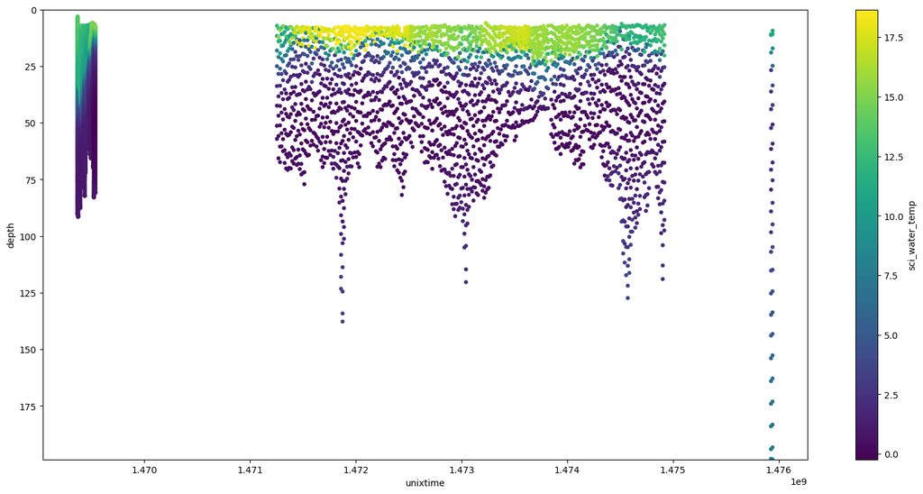

```python
# Import Pandas module
import pandas as pd

# Read data from file
glider_data = pd.read_csv('glider_data.csv',sep=',')

# Quality Control: Filter out data above 40oC and below -8oC
glider_data = glider_data[(glider_data.sci_water_temp < 40) & (glider_data.sci_water_temp > -8)]

# Quality Control: Filter out data too close to the surface
glider_data = glider_data[glider_data.depth > 3]

# Make a scatter plot
glider_data.plot.scatter('unixtime',
                         'depth',
                         c='sci_water_temp',
                         marker='o',
                         edgecolor='none',
                         cmap='viridis',
                         ylim=[glider_data['depth'].max(),0],
                         figsize=[19,9])
```

It is also useful to plot the glider path from above (i.e. "bird's eye" view). We can do that with the .plot method:

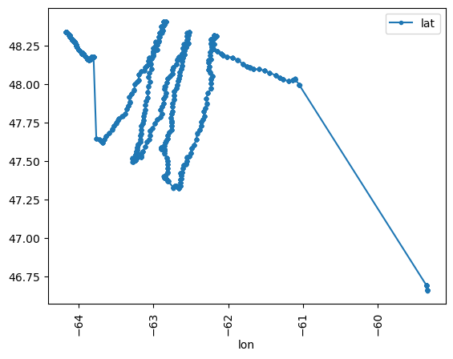

```python
# Bird's eye view transect
glider_data.plot(x='lon',y='lat',style='.-', rot=90)
```

You can see "gaps" where the glider was moving, but not recording. You can also see those gaps in the color-plot of temperature/depth/time shown above.

Take a look inside `glider_data`

```python
glider_data.head()
```

|  | unixtime | lat | lon | depth | sci_water_temp |
| --- | --- | --- | --- | --- | --- |
| 1 | 1.469369e+09 | 48.337438 | -64.171928 | 90.088686 | 0.9753 |
| 2 | 1.469369e+09 | 48.337437 | -64.171921 | 90.123090 | 0.9856 |
| 3 | 1.469369e+09 | 48.337436 | -64.171909 | 90.179436 | 0.9772 |
| 4 | 1.469369e+09 | 48.337435 | -64.171897 | 90.240740 | 0.9767 |
| 5 | 1.469369e+09 | 48.337433 | -64.171884 | 90.303295 | 0.9759 |

Tough question: What is the maximum depth recorded in this dataset? Hint: Apply the **.max** method on the "depth" column.

What is the **maximum** depth recorded in glider_data?

a) 125.1  
b) 198.6  
c) 145.2  
d) 250.0

More tough questions:

What is the **maximum** water temperature recorded in the "sci_water_temp" column within glider_data?

a) 10.1  
b) 23.6  
c) 18.7  
d) 9.2

What is the **minimum** water temperature recorded in the "sci_water_temp" column within glider_data?

a) -10.1  
b) 3.6  
c) 0.7  
d) -0.2

How many records are in the "sci_water_temp" column within glider_data?

a) 2356  
b) 798  
c) 10731  
d) 359712

## Installing new modules

[figure not shown]

Before we do our last "Real-life case study", we need to install 3 modules that do not come pre-installed with `Anaconda`. There are several ways to install Python modules and libraries, here we will use `conda`. Note that normally you only need to install a module once (it will remain installed until you manually remove it).

Most likely you already did this BEFORE the workshop started (instructions at the top of this manual). However, if you didn't here are the instructions to install the 3 modules (i.e. netcdf4, cartopy and cmocean). I'll explain what these modules do later.

When you need to install additional Python modules or libraries, you will need the **Anaconda Prompt** if you are in Windows, or if you are a Mac user, you can simply use Mac's built it terminal.

In Windows, search in the taskbar for **"Anaconda Prompt"** (in Mac, search for **"terminal"** in the Launchpad). The terminal should look a bit like this:

[figure not shown]

In the following section we will need the modules `netcdf4`, `catopy` and `cmocean`. You probably installed this BEFORE the beginning of this workshop. However, if you haven't installed them yet.... take a look at the instructions at the top of this document.

## Real-life case study #3: Sea Surface Temperature from Satellites

[figure not shown]

Some satellites can measure Sea Surface Temperature (SST) using optical sensors that capture infrared radiation coming from the ocean.

If you haven't installed `netcdf4`, `catopy` and `cmocean` yet.... take a look at the section at the top of this document.

For the following section, you will need to have the data file satellite_data.nc, already downloaded in your working directory (you probably already did this before the start of this workshop). Note that this is a "NetCDF" file, which is a binary format very compressed, made to store and transfer large datasets, but you cannot just open it in Excel. That is why we installed the `netcdf4` module.

Note that the code below is pretty much "the real deal". It is as complicated as it gets with Python, yet it is just a series of statements declaring variables and applying functions and methods. Note that, **by convention**, at the top of the file you import all the modules yo need.

```
<cartopy.mpl.feature_artist.FeatureArtist at 0x28f3d65d110>
```

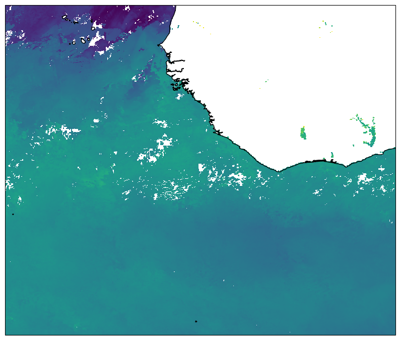

```python
import netCDF4
import numpy as np
import matplotlib.pyplot as plt
import cartopy.crs as ccrs
import cartopy.feature as cfeature
import cmocean

# open NetCDF data
nc = netCDF4.Dataset('satellite_data.nc')
ncv = nc.variables

# Extract variables of interest from inside the NetCDF file
lon = ncv['longitude'][:]
lat = ncv['latitude'][:]
sst = ncv['sstMasked'][0,:,:]

# Make grids of lats and lons for later use to make maps
lons, lats = np.meshgrid(lon,lat) #Note that you can create 2 variables (lons and lats) in one single statement


#%% Create map (PlateCarree Projection)
fig = plt.figure(figsize=(10,10)) # Create figure
ax = plt.axes(projection=ccrs.PlateCarree()) # Create axis within figure (with projection)
ax.pcolormesh(lons, lats, sst, transform=ccrs.PlateCarree()) # Add colormap to axis (specifying projection of data)
ax.coastlines(resolution='10m') # Add coastline to axis
```

Take a look at the generated map. You can see the colder water at the north, and warmer water in the center of the map.

What do you think is the average temperature in the whole map?

Luckily this is easy to find by applying the **.mean** method to out Sea Surface Temperature data (sst):

```python
sst.mean()
```

```
26.957568529476692
```

Lets see if you can figure out what are the minimum and the maximum temperatures is sst.

What is the **minimum** recorded Sea Surface Temperature in the sst data?

What is the **maximum** recorded Sea Surface Temperature in the sst data?

### Nicer maps (cartopy)

Lets do a slightly fancier map of the same data. This time using a "Lamber Conformal Conic Projection".

Since the satellite data is still "in memory" (assuming that you executed the code above, and did not turn off your computer since then), we can simply create the new map with the new projection.

We'll only use this map once, thus we can copy-paste into the "Console":

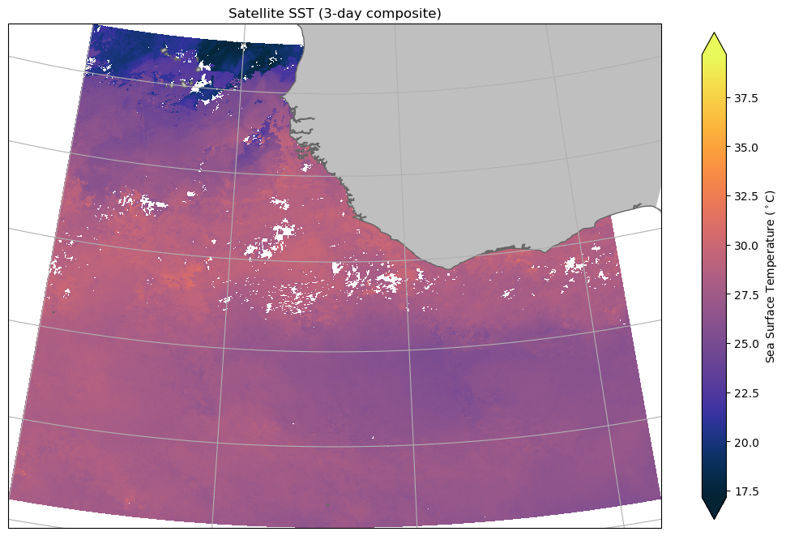

```python
#%% Create map (LambertConformal Projection)
# Create figure
fig = plt.figure(figsize=(13,13))
# Create axis within figure (with projection)
ax = plt.axes(projection=ccrs.LambertConformal(central_longitude=(lon.max()+lon.min())/2, central_latitude=(lat.max()+lat.min())/2))
# Add colormap to axis (specifying projection of data)
cs = ax.pcolormesh(lons, lats, sst, cmap=cmocean.cm.thermal, transform=ccrs.PlateCarree())
# Add colorbar
cbar = fig.colorbar(cs, shrink=0.6, orientation='vertical', extend='both')
# Add legend to colorbar
cbar.set_label('Sea Surface Temperature ($^\circ$C)')
 # Add land to axis
ax.add_feature(cfeature.NaturalEarthFeature(category='physical', scale='10m',facecolor='none', name='coastline'),
               edgecolor='#666666', facecolor='#bfbfbf')
# Add gridlines to axis
ax.gridlines()
# Add title to figure
plt.title('Satellite SST (3-day composite)')
```

Cartopy is a powerful module to create maps. We don't have time to deep-dive into it today, but feel free to explore other projections and make some extra maps. Here are some Galleries:

https://scitools.org.uk/cartopy/docs/latest/gallery/index.html

From the code above... which of the following are **"functions"** or **"methods"**?

Note that these **"functions"** or **"methods"** have fixed names, the coder has no choice but to use the correct **"function"** or **"method"** names.

From the code above... which of the following are **"variables"**?

Note that these **variables** have names that the coder chose (e.g. a coder can write **a** = 1 ... or **b** = 1 ... or **alpha** = 1 ... or **my_variable** = 1).

From the code above... in the line

```
fig = plt.figure(figsize=(13,13))
```

What is **fig**?

From the code above... in the line

```
fig = plt.figure(figsize=(13,13))
```

What is **plt.figure**?

From the code above... in the line

```
cbar = fig.colorbar(cs, shrink=0.6, orientation='vertical', extend='both') )
```

What is **.colorbar**?

## Data Management with ERDDAP

[figure not shown]

Data management (as an administrator) is a complicated topic that requires months of training to do properly. But in summary, if you have oceanographic data that you need to store, manage, and serve to end-users... you should look into ERDDAP!

ERDDAP:

- It was developed by NOAA as a free open-source software.
- Allows computer-human downloads (i.e. through a browser).
- Allows computer-computer downloads (i.e. no browser. E.g. download data using Python, R, Matlab, etc.).
- Many Governments and Oceanographic Institutions now serve their data using ERDDAP.

Setting up an ERDDAP server (the administrator's job) is beyond the scope of this workshop. However, learning how to use it (as a client, or end-user) is easy, and incredibly useful.

Here is a list of a few ERDDAP servers:

- NOAA CoastWatch: https://coastwatch.noaa.gov/erddap/index.html
- Dalhousie University CEOTR: https://ceotr.ocean.dal.ca/erddap/index.html
- Biological & Chemical Oceanography Data Management Office: https://erddap.bco-dmo.org/erddap/index.html
- University of Hawaii: https://erddap.bco-dmo.org/erddap/index.html
- PermafrontNet: https://data.permafrostnet.ca/erddap/index.html
- University of British Columbia: https://salishsea.eos.ubc.ca/erddap/index.html

You can also use the following ERDDAP search engine to find ERRAP servers around the world: http://erddap.com/

### Example of using an ERDDAP server

Go to https://coastwatch.noaa.gov/erddap/index.html

On the search box (top-right), search for: SST

You should see a list of data products. Find the product named "Sea Surface Temperature, NOAA Coral Reef Watch Daily Global 5km Satellite SST (CoralTemp), 1985-present, Daily".

Click on the "graph" link for that product (see arrow in image below)

[figure not shown]

You should be able to see a webpage similar to the one below:

[figure not shown]

From here, you should be able to click on the map (to center) and zoom in or out to get the region that you are interested in.

Then, on the field `Then set the File Type:` select `.nc`

Then, click on `Download the Data or an Image`

This should trigger a download of the data into your "Downloads" folder. Move this newly downloaded file to your **"WYTEC_Python_Workshop"** folder.

In my case the downloaded file was named `noaacrwsstDaily_2830_f4c9_5547_U1710527396048.nc`, but for you it will be a different name.

In Spyder's **Editor** open a new file and save it as new_plot.py.

Copy-paste the code below.

Make sure you change the filename to reflect the filename of **YOUR** downloaded file

... click

```python
import netCDF4
import numpy as np
import matplotlib.pyplot as plt
import cartopy.crs as ccrs

# open NetCDF data. Use the filename of YOUR dowloaded file!!
nc = netCDF4.Dataset('noaacrwsstDaily_2830_f4c9_5547_U1710527396048.nc') #Use filename of YOUR downloaded file
ncv = nc.variables
```

The code above loaded the `.nc` file. Now you have to dig in the file and see information about the variables that are included in the file. The information you need is (1) variable names, and (2) their dimenssions. To figure that out type the following in the console:

```python
ncv
```

```
{'time': <class 'netCDF4._netCDF4.Variable'>
 float64 time(time)
     _CoordinateAxisType: Time
     actual_range: [1.7103312e+09 1.7103312e+09]
     axis: T
     coverage_content_type: coordinate
     ioos_category: Time
     long_name: Time
     standard_name: time
     time_origin: 01-JAN-1970 00:00:00
     units: seconds since 1970-01-01T00:00:00Z
 unlimited dimensions:
 current shape = (1,)
 filling on, default _FillValue of 9.969209968386869e+36 used,
 'latitude': <class 'netCDF4._netCDF4.Variable'>
 float32 latitude(latitude)
     _CoordinateAxisType: Lat
     actual_range: [-15.375  18.225]
     axis: Y
     comment: equirectangular projection and grid centers
     coverage_content_type: coordinate
     ioos_category: Location
     long_name: Latitude
     standard_name: latitude
     units: degrees_north
     valid_max: 89.975
     valid_min: -89.975
 unlimited dimensions:
 current shape = (673,)
 filling on, default _FillValue of 9.969209968386869e+36 used,
 'longitude': <class 'netCDF4._netCDF4.Variable'>
 float32 longitude(longitude)
     _CoordinateAxisType: Lon
     actual_range: [-31.575   2.025]
     axis: X
     comment: equirectangular projection and grid centers
     coverage_content_type: coordinate
     ioos_category: Location
     long_name: Longitude
     standard_name: longitude
     units: degrees_east
     valid_max: 179.975
     valid_min: -179.975
 unlimited dimensions:
 current shape = (673,)
 filling on, default _FillValue of 9.969209968386869e+36 used,
 'analysed_sst': <class 'netCDF4._netCDF4.Variable'>
 float64 analysed_sst(time, latitude, longitude)
     _FillValue: -327.68
     colorBarMaximum: 40.0
     colorBarMinimum: 0.0
     coverage_content_type: physicalMeasurement
     ioos_category: Temperature
     long_name: analysed sea surface temperature
     standard_name: sea_surface_temperature
     units: degree_C
     valid_max: 50.0
     valid_min: -2.0
 unlimited dimensions:
 current shape = (1, 673, 673)
 filling on}
```

As you can see, the variables (and thier shapes) in the `.nc` file are:

- 'time', shape = (1,)
- 'latitude', shape = (673,)
- 'longitude', shape = (673,)
- and 'analysed_sst', shape = (1, 673, 673)

Now we'll use the code below to extract these variables from the `.nc` file into Python variables that are easy to handle. Copy-paste the code below into your new_plot.py file and click [run].

```python
# Extract variables of interest from inside the NetCDF file
lon = ncv['longitude'][:]
lat = ncv['latitude'][:]
data = ncv['analysed_sst'][0,:,:]
```

Finally, lets make a grid... and plot the data, by copy-pasting the code below into your new_plot.py file and click [run].

```
<cartopy.mpl.feature_artist.FeatureArtist at 0x28f3d81b310>
```

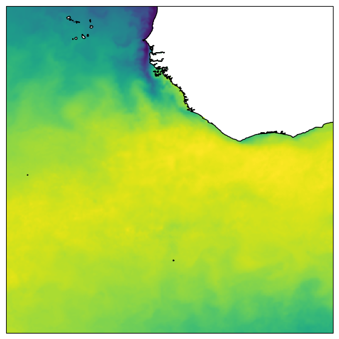

```python
# Make grids of lats and lons for later use to make maps
lons, lats = np.meshgrid(lon,lat)

#%% Create map (PlateCarree Projection)
fig = plt.figure(figsize=(7,7)) # Create figure
ax = plt.axes(projection=ccrs.PlateCarree()) # Create axis within figure (with projection)
ax.pcolormesh(lons, lats, data, transform=ccrs.PlateCarree()) # Add colormap to axis (specifying projection of data)
ax.coastlines(resolution='10m') # Add coastline to axis
```

Note that this data (i.e. "Sea Surface Temperature, NOAA Coral Reef Watch Daily Global 5km Satellite SST" aka: CoralTemp) is similar to the previous example that we just did before. But this data set does not have any gaps, because it is a composite of several gap-free data products.

Try exploring other data products from ERDDAP. As long as you choose "MAPS" (i.e. 2-dimensional geospatial products), you should be able to adapt the code above. Just pay attention to the name of the variables and their shapes. )

# **This is the end of lab**

Code below is for formatting of this lab. Do not alter!

```python
# Loads css file and applies it to lab HTML
from IPython.core.display import HTML
def css():
    style = open("../css/custom.css", "r").read()
    return HTML(style)
css()
```